# Part ivC: Visualizing trends for a difficult customer

INFSCI 2595 Final

Ben Stein

4/27/2022

# About this document

In this document, I visualize trends for the most difficult-to-predict customer in the **regression** problem: customer K.

# Setup

## Libraries & tools

```r
library(tidyverse)
library(caret)
library(vip)
library(xgboost)
source("./tools.R")
```

## Data

```r
df <- load_project_data() %>%
  select(-outcome_numeric) %>%
  filter(customer == "K")
```

## “Best” model

```r
best_reg_model <- load_model("adv_reg_model9_xgb.rds")
```

# Visualization

**NOTE:** My best-performing regression model was an SVM for which I was unable to produce variable importance. Instead, I perform the analysis below using my second-best regression model (XGBoost) to ensure that I’m using the most important features from that model.

## Important variables

Recall our most important variables:

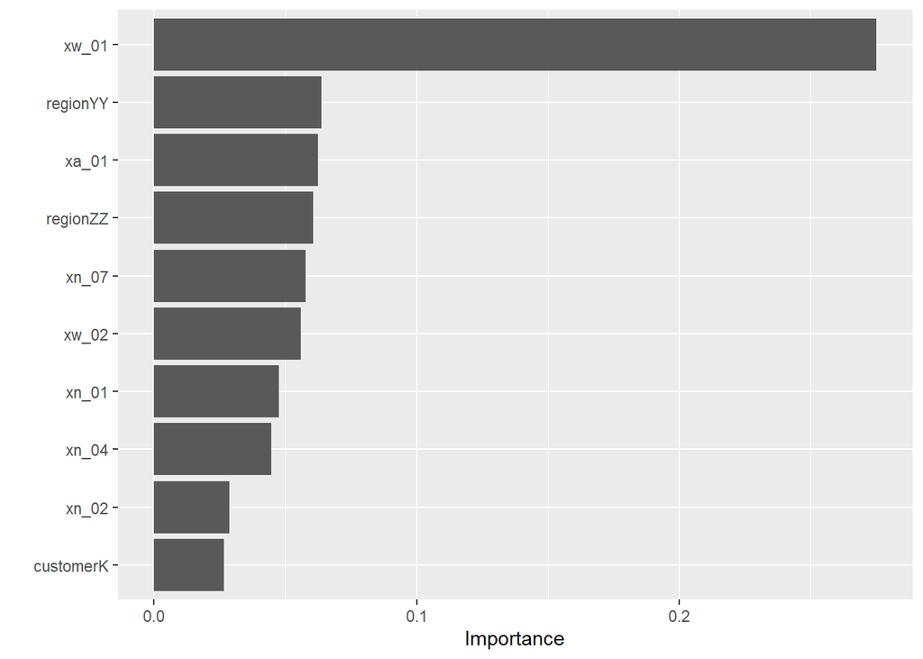

```r
vip::vip(best_reg_model$finalModel)
```

## Trends

### `xw_01` and `region`

These were the two most predictive variables in this model. Let’s explore them:

```r
viz_grid_xw_01_region <- append(
  expand.grid(
    customer = names(which.max(table(df$customer))),
    region = df$region,
    xw_01 = seq(
      min(df$xw_01),
      max(df$xw_01),
      length.out = 101
    )
  ),
  df %>%
    select(
      -customer,
      -region,
      # Leaving the observed response here - I address why below
      # -response_log,
      -xw_01
    ) %>%
    colMeans
) %>% as_tibble

viz_grid_xw_01_region
```

```
## # A tibble: 3,838 x 36
##    customer region xw_01 xb_01 xb_02 xb_03 xn_01 xn_02 xn_03 xa_01 xa_02 xa_03
##    <fct>    <fct>  <dbl> <dbl> <dbl> <dbl> <dbl> <dbl> <dbl> <dbl> <dbl> <dbl>
##  1 K        ZZ        12  3.67  5.16  2.39  1.04  2.13     0  6.83  10.2  4.26
##  2 K        ZZ        12  3.67  5.16  2.39  1.04  2.13     0  6.83  10.2  4.26
##  3 K        ZZ        12  3.67  5.16  2.39  1.04  2.13     0  6.83  10.2  4.26
##  4 K        ZZ        12  3.67  5.16  2.39  1.04  2.13     0  6.83  10.2  4.26
##  5 K        ZZ        12  3.67  5.16  2.39  1.04  2.13     0  6.83  10.2  4.26
##  6 K        ZZ        12  3.67  5.16  2.39  1.04  2.13     0  6.83  10.2  4.26
##  7 K        ZZ        12  3.67  5.16  2.39  1.04  2.13     0  6.83  10.2  4.26
##  8 K        ZZ        12  3.67  5.16  2.39  1.04  2.13     0  6.83  10.2  4.26
##  9 K        ZZ        12  3.67  5.16  2.39  1.04  2.13     0  6.83  10.2  4.26
## 10 K        ZZ        12  3.67  5.16  2.39  1.04  2.13     0  6.83  10.2  4.26
## # ... with 3,828 more rows, and 24 more variables: xb_04 <dbl>, xb_05 <dbl>,
## #   xb_06 <dbl>, xb_07 <dbl>, xb_08 <dbl>, xn_04 <dbl>, xn_05 <dbl>,
## #   xn_06 <dbl>, xn_07 <dbl>, xn_08 <dbl>, xa_04 <dbl>, xa_05 <dbl>,
## #   xa_06 <dbl>, xa_07 <dbl>, xa_08 <dbl>, xw_02 <dbl>, xw_03 <dbl>,
## #   xs_01 <dbl>, xs_02 <dbl>, xs_03 <dbl>, xs_04 <dbl>, xs_05 <dbl>,
## #   xs_06 <dbl>, response_log <dbl>
```

Visualizing the trends:

```r
# Demonstrating that predict can't do CI for SVMs:
predict(best_reg_model, viz_grid_xw_01_region, interval = "confidence") %>% head(10)
```

```
##  [1] 0.2451481 0.2451481 0.2451481 0.2451481 0.2451481 0.2451481 0.2451481
##  [8] 0.2451481 0.2451481 0.2451481
```

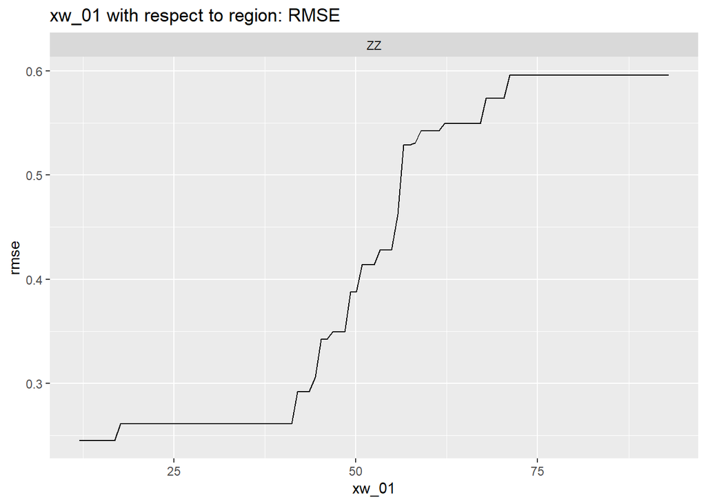

```r
viz_grid_xw_01_region %>%
  rename(obs = response_log) %>%
  mutate(
    pred = predict(best_reg_model, viz_grid_xw_01_region),
    rmse = RMSE(pred, obs)
  ) %>%
  ggplot(mapping = aes(x = xw_01, y = rmse)) +
    ggtitle("xw_01 with respect to region: RMSE") +
    geom_line(mapping = aes(y = pred)) +
    facet_wrap(~ region)
```

Okay, so the `region` facet doesn’t turn out to be all that interesting (which I should have realized in advance, since a customer is likely only in one region), but we can still see how `xw_01` works. There’s a very clear trend between the word count feature and RMSE. Let’s facet by something more interesting, though:

### `xw_01` and `xa_01`

```r
viz_grid_xw_01_xa_01 <- append(
  expand.grid(
    customer = "K",
    region = "ZZ",
    xw_01 = seq(
      min(df$xw_01),
      max(df$xw_01),
      length.out = 101
    ),
    xa_01 = seq(
      min(df$xa_01),
      max(df$xa_01),
      length.out = 9
    )
  ),
  df %>%
    select(
      -customer,
      -region,
      # Leaving the observed response here - I address why below
      # -response_log,
      -xw_01,
      -xa_01
    ) %>%
    colMeans
) %>% as_tibble

viz_grid_xw_01_xa_01
```

```
## # A tibble: 909 x 36
##    customer region xw_01 xa_01 xb_01 xb_02 xb_03 xn_01 xn_02 xn_03 xa_02 xa_03
##    <fct>    <fct>  <dbl> <dbl> <dbl> <dbl> <dbl> <dbl> <dbl> <dbl> <dbl> <dbl>
##  1 K        ZZ      12     1.5  3.67  5.16  2.39  1.04  2.13     0  10.2  4.26
##  2 K        ZZ      12.8   1.5  3.67  5.16  2.39  1.04  2.13     0  10.2  4.26
##  3 K        ZZ      13.6   1.5  3.67  5.16  2.39  1.04  2.13     0  10.2  4.26
##  4 K        ZZ      14.4   1.5  3.67  5.16  2.39  1.04  2.13     0  10.2  4.26
##  5 K        ZZ      15.2   1.5  3.67  5.16  2.39  1.04  2.13     0  10.2  4.26
##  6 K        ZZ      16.0   1.5  3.67  5.16  2.39  1.04  2.13     0  10.2  4.26
##  7 K        ZZ      16.9   1.5  3.67  5.16  2.39  1.04  2.13     0  10.2  4.26
##  8 K        ZZ      17.7   1.5  3.67  5.16  2.39  1.04  2.13     0  10.2  4.26
##  9 K        ZZ      18.5   1.5  3.67  5.16  2.39  1.04  2.13     0  10.2  4.26
## 10 K        ZZ      19.3   1.5  3.67  5.16  2.39  1.04  2.13     0  10.2  4.26
## # ... with 899 more rows, and 24 more variables: xb_04 <dbl>, xb_05 <dbl>,
## #   xb_06 <dbl>, xb_07 <dbl>, xb_08 <dbl>, xn_04 <dbl>, xn_05 <dbl>,
## #   xn_06 <dbl>, xn_07 <dbl>, xn_08 <dbl>, xa_04 <dbl>, xa_05 <dbl>,
## #   xa_06 <dbl>, xa_07 <dbl>, xa_08 <dbl>, xw_02 <dbl>, xw_03 <dbl>,
## #   xs_01 <dbl>, xs_02 <dbl>, xs_03 <dbl>, xs_04 <dbl>, xs_05 <dbl>,
## #   xs_06 <dbl>, response_log <dbl>
```

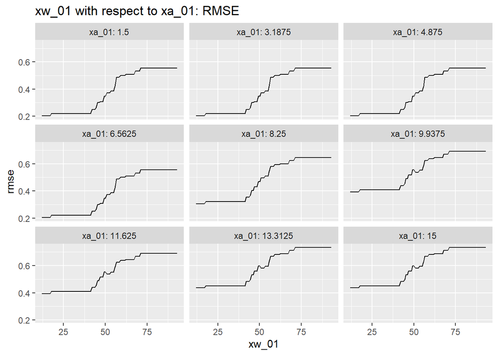

```r
viz_grid_xw_01_xa_01 %>%
  rename(obs = response_log) %>%
  mutate(
    pred = predict(best_reg_model, viz_grid_xw_01_xa_01),
    rmse = RMSE(pred, obs)
  ) %>%
  ggplot(mapping = aes(x = xw_01, y = rmse)) +
    ggtitle("xw_01 with respect to xa_01: RMSE") +
    geom_line(mapping = aes(y = pred)) +
    facet_wrap(~ xa_01, labeller = label_both)
```

We see a similar trend across all values of `xa_01`, with low values of `xw_01` having low error. We can see that the amount of error also increases as we reach medium and higher values of `xa_01`. This is interesting, though - `xa_01` is a sentiment variable, while `xw_01` is a word-count-related one, but high values of both result in higher error.